# Data Analysis Project

Seleznev Ilya, Tsatsuev Savelii, Sviridenko Ekaterina, Vartanyan Alexandra

2024-05-05

# Project 1

Country: France

Topic: Trust and politics

Names:Вартаньян Александра,Свириденко Екатерина,Цацуев Савелий,Селезнев Илья.

Contributions: Вартаньян Александра - box plot (vote & age; petition & age), scatterplot, stacked bar plot, findings, conclusion Свириденко Екатерина - box plot, bar plot, research question, research interest Цацуев Савелий - how satisfied are French people with the national government, is there an association between time a person watches, reads or listens to news about politics and current affairs and their trust in legal system? Селезнев Илья - dataset, variables’ meaning and levels, central tendency measures, boxplot trust police and gender, boxplot cptppola, stflife

Research interest: In recent years, more and more protests started to take place in France as a sign of discontent and distrust of French citizens with the actions of politicians and the government. The political and civic situation, the level of civic engagement in the country attracts interest. Hooghe and Marien in their article touch upon the idea that “political trust will only have these behavioral consequences if it is associated with sufficiently high levels of political efficacy”(Hooghe & Marien, 2013). The idea has developed our research interest in the topic: in this project we explored characteristics of people, both personal and social, that we assume might influence political trust and participation of a person, as well as French citizens’ thoughts on their ability and confidence to participate and make an impact. More precisely, for example, Melo and Stockemer as the result of their research on political participation done in 3 countries(Germany, France, UK) found that “the relationship between age and various forms of political engagement is frequently not linear. While some forms of political involvement are strongest among the elderly (that is voting), other types are more pronounced among individuals between the ages of 34 and 65 (that is signing petitions) or the young (that is participation in demonstrations)”(Melo & Stockemer, 2012). In this project, we attempt to see if the results for our data will be similar.

References: Hooghe, M., & Marien, S. (2013). A COMPARATIVE ANALYSIS OF THE RELATION BETWEEN POLITICAL TRUST AND FORMS OF POLITICAL PARTICIPATION IN EUROPE. European Societies, 15(1), 131–152. https://doi.org/10.1080/14616696.2012.692807 Melo, D., & Stockemer, D. (2012). Age and political participation in Germany, France and the UK: A comparative analysis. Comparative European Politics, 12(1), 33–53. https://doi.org/10.1057/cep.2012.31

Research question:

How are citizens’ of France opinions on politics influence their political participation?

## Loading data, running libraries.

```r
library(readr)
library(dplyr)
library(haven)
library(knitr)
library(ggplot2)
library(kableExtra)
library(foreign)
library(dplyr)
library(ggplot2)
library(psych)
library(xfun)
library(sjPlot)
library(rstatix)
library(FSA)
library(tidyverse)
library(car)
library(ggpubr)
library(lsr)
library(DescTools)
library(effects)
library(jtools)
library(ggstatsplot)
library(interplot)
```

## Dataset, variables’ meanings and levels.

```r
ESS = read_sav("ESS10-subset.sav")
ESS_pol=ESS%>%
  dplyr::select(stfgov, trstlgl, vote, agea, psppipla, actrolga, nwspol, cptppola, trstplc, gndr, stflife, sgnptit)%>%
  na.omit()

Label = c("`stfgov`", "`trstplc`", "`gndr`", "`trstlgl`", "`vote`", "`agea`", "`psppipla`", "`actrolga`", "`nwspol`", "`cptppola`", "`stflife`", "`sgnptit`")
Meaning = c("How satisfied with the national government", "Trust in the police", "Gender", "Trust in the legal system", "Voted last national election", "Age of respondent, calculated", "Political system allows people to have influence on politics", "Able to take active role in political group", "News about politics and current affairs, watching, reading or listening, in minutes", "Confident in own ability to participate in politics", "How satisfied with life as a whole", "Signed petition last 12 months")
Level_Of_Measurement <- c("Quasi-interval (as numeric)", "Quasi-interval (as numeric)", "Nominal", "Quasi-interval (as numeric)", "Binary",  "Interval", "Ordinal", "Ordinal", "Ratio", "Ordinal", "Quasi-interval (as numeric)", "Binary")
df <- data.frame(Label, Meaning, Level_Of_Measurement, stringsAsFactors = FALSE)

kable(df) %>%
  kable_styling(bootstrap_options=c("bordered", "responsive","striped"), full_width = FALSE)
```

| Label | Meaning | Level_Of_Measurement |
| --- | --- | --- |
| `stfgov` | How satisfied with the national government | Quasi-interval (as numeric) |
| `trstplc` | Trust in the police | Quasi-interval (as numeric) |
| `gndr` | Gender | Nominal |
| `trstlgl` | Trust in the legal system | Quasi-interval (as numeric) |
| `vote` | Voted last national election | Binary |
| `agea` | Age of respondent, calculated | Interval |
| `psppipla` | Political system allows people to have influence on politics | Ordinal |
| `actrolga` | Able to take active role in political group | Ordinal |
| `nwspol` | News about politics and current affairs, watching, reading or listening, in minutes | Ratio |
| `cptppola` | Confident in own ability to participate in politics | Ordinal |
| `stflife` | How satisfied with life as a whole | Quasi-interval (as numeric) |
| `sgnptit` | Signed petition last 12 months | Binary |

## Caclulating Central Tendency Measures.

```r
Mode <- function(x) {
  ux <- unique(x)
  ux[which.max(tabulate(match(x, ux)))]
}
#1
ESS_pol$stfgov =  as.numeric(as.character(ESS_pol$stfgov))
v.stfgov <- c(mean(ESS_pol$stfgov), Mode(ESS_pol$stfgov), median(ESS_pol$stfgov))
names(v.stfgov) <- c("mean", "mode", "median")
#2
ESS_pol$trstlgl =  as.numeric(as.character(ESS_pol$trstlgl))
v.trstlgl <- c(mean(ESS_pol$trstlgl), Mode(ESS_pol$trstlgl), median(ESS_pol$trstlgl))
names(v.trstlgl) <- c("mean", "mode", "median")
#3
ESS_pol$agea = as.numeric(as.character(ESS_pol$agea))
v.agea <- c(mean(ESS_pol$agea), Mode(ESS_pol$agea), median(ESS_pol$agea))
names(v.agea) <- c("mean", "mode", "median")
#4
ESS_pol$nwspol = as.numeric(as.character(ESS_pol$nwspol))
v.nwspol <- c(mean(ESS_pol$nwspol), Mode(ESS_pol$nwspol), median(ESS_pol$nwspol))
names(v.nwspol) <- c("mean", "mode", "median")
#5
ESS_pol$trstplc = as.numeric(as.character(ESS_pol$trstplc))
v.trstplc <- c(mean(ESS_pol$trstplc), Mode(ESS_pol$trstplc), median(ESS_pol$trstplc))
names(v.trstplc) <- c("mean", "mode", "median")
#6
ESS_pol$stflife = as.numeric(as.character(ESS_pol$stflife))
v.stflife <- c(mean(ESS_pol$stflife), Mode(ESS_pol$stflife), median(ESS_pol$stflife))
names(v.stflife) <- c("mean", "mode", "median")

СTM =  data.frame(v.stfgov, v.trstlgl, v.agea, v.nwspol, v.trstplc, v.stflife, stringsAsFactors = FALSE)

kable(СTM) %>%
  kable_styling(bootstrap_options=c("bordered", "responsive","striped"), full_width = FALSE)
```

|  | v.stfgov | v.trstlgl | v.agea | v.nwspol | v.trstplc | v.stflife |
| --- | --- | --- | --- | --- | --- | --- |
| mean | 4.723145 | 5.189369 | 49.49225 | 83.87929 | 6.351052 | 7.011074 |
| mode | 5.000000 | 5.000000 | 51.00000 | 60.00000 | 7.000000 | 8.000000 |
| median | 5.000000 | 5.000000 | 50.00000 | 60.00000 | 7.000000 | 7.000000 |

## Graphs creating:

Q1: What are French people’s thoughts on their ability to take active role in political group?

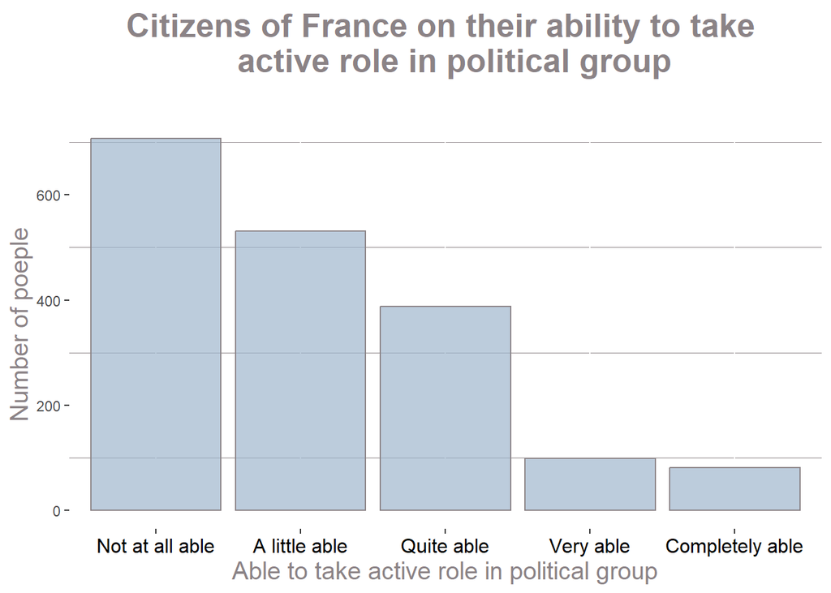

```r
ESS_pol = ESS_pol%>%
  filter(actrolga != 8 )%>%
  filter(actrolga!= 9 )%>%
  filter(actrolga != 7 )

ESS_pol$actrolga<-factor(ESS_pol$actrolga,labels=c("Not at all able","A little able",
  "Quite able","Very able","Completely able"),ordered=F,exclude=NA)

ggplot(ESS_pol)+
  geom_bar(aes(actrolga),fill="#9FB6CD",alpha=0.7,colour='#8B8386')+
  labs(title= "Citizens of France on their ability to take
  active role in political group
",x= "Able to take active role in political group", y="Number of poeple")+
  theme(plot.title=element_text(face="bold",size=20, vjust=0.5,colour='#8B8386',hjust = 0.5),
        panel.background = element_rect(fill='white'),
        panel.grid.minor = element_line(colour='#8B8386'),
        axis.title.x = element_text(color="#8B8386",size= 15),
        axis.text.x = element_text(color="black",size = 12),
        axis.title.y = element_text(color="#8B8386",size= 15))
```

Conclusion 1: Citizens of France mostly believe they are not able to take active role in political group

Q2: How satisfied are French people with the national government?

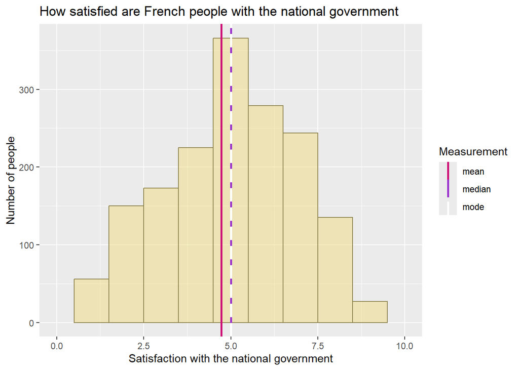

```r
ggplot()+
  geom_histogram(data = ESS_pol, aes(x = stfgov), binwidth = 1, fill="#EEDC82", col="lightgoldenrod4", alpha = 0.5) +
  xlim(c(0, 10)) +
  xlab("Satisfaction with the national government") +
  ylab("Number of people") +
  geom_vline(aes(xintercept = mean(ESS_pol$stfgov), color = 'mean'), linetype="solid", size=1) +
  geom_vline(aes(xintercept = median(ESS_pol$stfgov), color = 'median'), linetype="solid", size=1)+
  geom_vline(aes(xintercept = Mode(ESS_pol$stfgov), color = 'mode'), linetype="longdash",size=1) +
  scale_color_manual(name = "Measurement", values = c(median = "#9A32CD", mean = "#CD1076", mode = "white"))+
  ggtitle("How satisfied are French people with the national government ")
```

Conclusion 2: We can see that satisfaction with the national government is distributed almost normally as we see an almost bell-shaped graph: the majority of answers are from 4 to 7, and 0, 1, 9 and 10 are actually very rare answers.

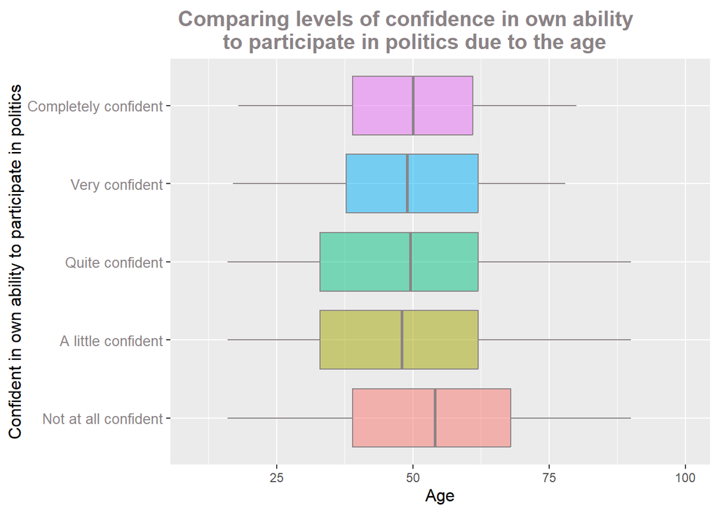

```r
ESS_pol=ESS_pol%>%
  filter( cptppola != 8 )%>%
  filter(cptppola!= 9 )%>%
  filter(cptppola != 7 )

ESS_pol$cptppola<-factor(ESS_pol$cptppola,labels=c("Not at all confident","A little confident",
"Quite confident","Very confident","Completely confident"),ordered=F,exclude=NA)

ggplot(ESS_pol)+
  geom_boxplot(aes(agea,cptppola,fill=cptppola),alpha=0.5,color="#8B8386")+
  xlim(10,100)+
  labs(title="Comparing levels of confidence in own ability
       to participate in politics due to the age",
       y="Confident in own ability to participate in politics",
      x="Age")+
      theme(plot.title=element_text(face="bold",size=15, ,vjust=0.5,colour='#8B8386',hjust = 0.1),
             axis.title.x = element_text(color="black",size= 12),
            axis.title.y = element_text(color="black",size= 12),
             axis.text.y = element_text(color="#8B8386",size = 10),
            legend.position=('none'))
```

Conclusion 3: As it is presented on the graph, there is no drastic difference in terms of age between different levels of one’s confidence in their own ability to participate in politics. We can see that older people have less confidence here.

Q4: Is there an relationship between time citizens watch, read or listen to news about politics and current affairs and their trust in legal system?

[figure not shown]

```r
ggplot(ESS_pol)+
  geom_point(aes(x=nwspol,y=trstlgl))+scale_x_continuous(limits=c(0,1500))+
  scale_y_continuous(limits=c(0,10),breaks=c(0, 1, 2, 3, 4, 5, 6, 7, 8, 9, 10))+
  xlab("Trust in the legal system") +
  ylab("News about politics") +
  ggtitle("Relationship between citizen's trust in the legal system
and the amount of time they watch, read or listen to news about politics") +
  theme_bw()
```

Q5: Is there a difference in relation to trust in the police depending on gender?

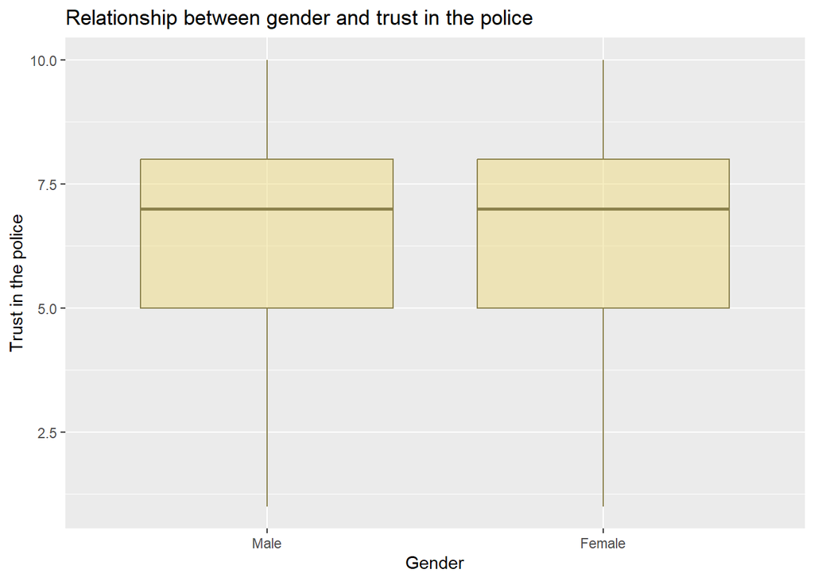

```r
ESS_pol = ESS_pol %>%
  filter(trstplc != 77 )%>%
  filter(trstplc != 88 )%>%
  filter(trstplc != 99 )

ESS_pol$gndr <- factor(ESS_pol$gndr, labels = c("Male", "Female"),ordered= F,exclude = NA)
ggplot() +
  geom_boxplot(data = ESS_pol, aes(x = gndr, y = trstplc), fill="lightgoldenrod2", col="lightgoldenrod4", alpha = 0.5) +
  ylim(c(1,10)) +
  xlab("Gender") +
  ylab("Trust in the police") +
  ggtitle("Relationship between gender and trust in the police")
```

Conclusion 5: As we found in France, both men and women have the same level of trust in police officers, the median of which is 7

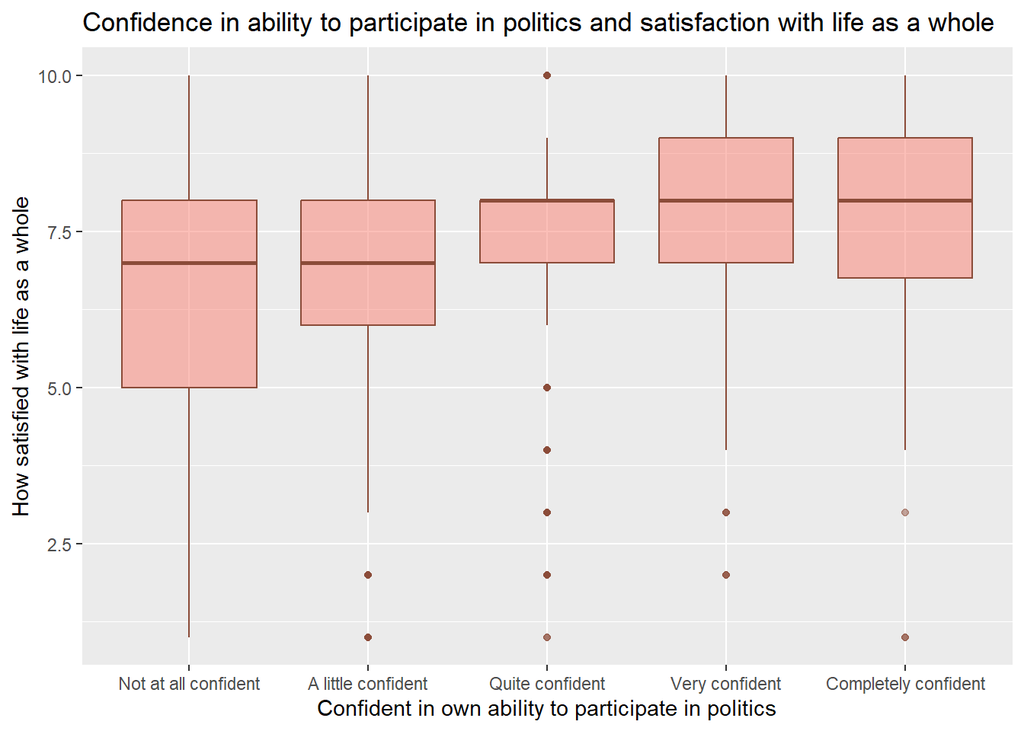

```r
ESS_pol = ESS_pol %>%
  filter(cptppola != 7 )%>%
  filter(cptppola != 8 )%>%
  filter(cptppola != 9 )
ESS_pol = ESS_pol %>%
  filter(stflife != 77 )%>%
  filter(stflife != 88 )%>%
  filter(stflife != 99 )

ESS_pol$cptppola <- factor(ESS_pol$cptppola, labels = c("Not at all confident", "A little confident", "Quite confident", "Very confident", "    Completely confident"),ordered= F)
ggplot() +
  geom_boxplot(data = ESS_pol, aes(x = cptppola, y = stflife), fill="#FA8072", col="#8B4C39", alpha = 0.5) +
  ylim(c(1,10)) +
  xlab("Confident in own ability to participate in politics") +
  ylab("How satisfied with life as a whole") +
  ggtitle("Confidence in ability to participate in politics and satisfaction with life as a whole")
```

Q7: How likely are people to vote in the last election if they are confident that the political system allows people to influence polictics?

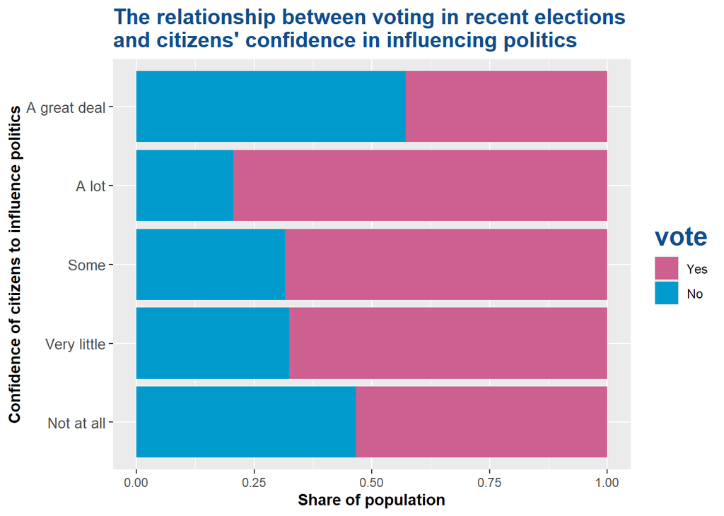

```r
ESS_pol = ESS_pol %>%
  filter(psppipla != 7) %>%
  filter(psppipla != 8) %>%
  filter(psppipla != 9)

ESS_pol$psppipla <- factor(ESS_pol$psppipla, labels = c("Not at all",
"Very little", "Some","A lot", "A great deal"), ordered = F)

ESS_pol = ESS_pol %>%
  filter(vote !=3) %>%
  filter(vote !=7) %>%
  filter(vote !=8) %>%
  filter(vote !=9)

ESS_pol$vote <- factor(ESS_pol$vote, labels = c("Yes", "No"), ordered = F)

ggplot(data=ESS_pol, aes(x=psppipla, fill = vote)) +
  geom_bar(position = "fill") +
  scale_fill_manual(values=c("#CD6090", "#009ACD", "#808080")) +
  coord_flip() +
  xlab("Confidence of citizens to influence politics") +
  ylab("Share of population") +
  ggtitle("The relationship between voting in recent elections
and citizens' confidence in influencing politics") +
  theme(plot.title = element_text(face="bold",size = 15, color="#104E8B"),
        legend.title=element_text(face="bold",size = 18, color="#104E8B"),
        axis.title.x=element_text(face="bold", color = "black"),
        axis.title.y=element_text(face="bold", color = "black"),
        axis.text.y = element_text(size = 10))
```

Q8: Is there any association between the time a person watches, reads or listens to news about politics and their life satisfaction about national government?

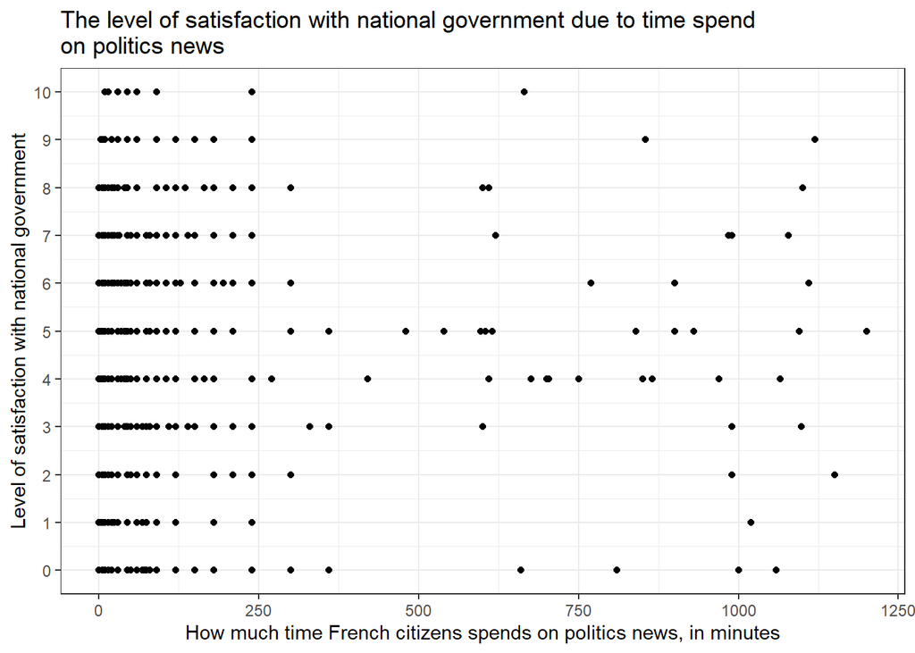

```r
ESS_pol$nwspol = as.numeric(as.character(ESS_pol$nwspol))
ESS_pol$stfgov  = as.numeric(as.character(ESS_pol$stfgov ))


ESS_pol = ESS_pol %>%
  filter(nwspol !=7777) %>%
  filter(nwspol !=8888) %>%
  filter(nwspol !=9999)

ESS_pol = ESS_pol %>%
  filter(stfgov !=77) %>%
  filter(stfgov !=88) %>%
  filter(stfgov !=99)


ggplot(data=ESS_pol) +
  geom_point(aes(x = nwspol, y = stfgov)) +
  scale_color_manual("#7B68EE", "#FFFF00") +
  xlab("How much time French citizens spends on politics news, in minutes") +
  ylab("Level of satisfaction with national government") +
  ggtitle("The level of satisfaction with national government due to time spend
on politics news") +
  scale_x_continuous(limits=c(0, 1200)) +
  scale_y_continuous(limits=c(0,10),breaks=c(0, 1, 2, 3, 4, 5, 6, 7, 8, 9, 10)) +
  theme_bw()
```

Conclusion 8: As we can see from the plot, correlation is nearer to zero, therefore there is no correlation between people’s time spending on politics news and their level of satisfaction with government

Q9: Is there any differences between people’s age and there participation in signing petition?

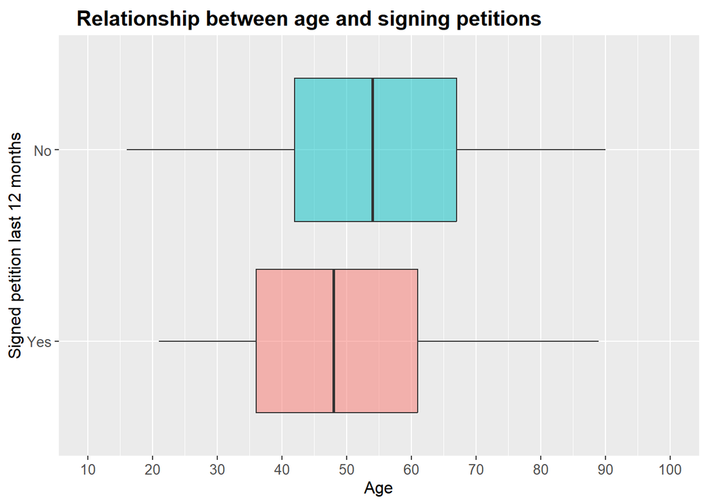

```r
ESS_pol = ESS_pol %>%
  filter(sgnptit !=77) %>%
  filter(sgnptit !=88) %>%
  filter(sgnptit !=99)

ESS_pol = ESS_pol %>%
  filter(agea !=999)

ESS_pol$agea = as.numeric(as.character(ESS_pol$agea))
ESS_pol$sgnptit = factor(ESS_pol$sgnptit, labels=c("Yes", "No"),
                         ordered=F)

ggplot(ESS_pol) +
  geom_boxplot(aes(agea, sgnptit, fill = sgnptit), alpha = 0.5) +
  scale_x_continuous(limits=c(10,100),breaks=c(10, 20, 30, 40, 50, 60, 70, 80,
                                               90, 100)) +
  labs(title="Relationship between age and signing petitions",
       y= "Signed petition last 12 months", x = "Age") +
  theme(plot.title = element_text(face="bold", size=15, vjust=0.5, hjust=0.1),
        axis.title.x = element_text(color="black", size=12),
        axis.title.y = element_text(color="black",size= 12),
        axis.text.y = element_text(size=10),
        axis.text.x = element_text(size=10),
        legend.position=("none"))
```

Conclusion 9: We can see that people from 30 to 50 years (middle-aged) signing petitions more than other aged groups.

Q10: Is there any differences between people’s age and their participation in voting last election?

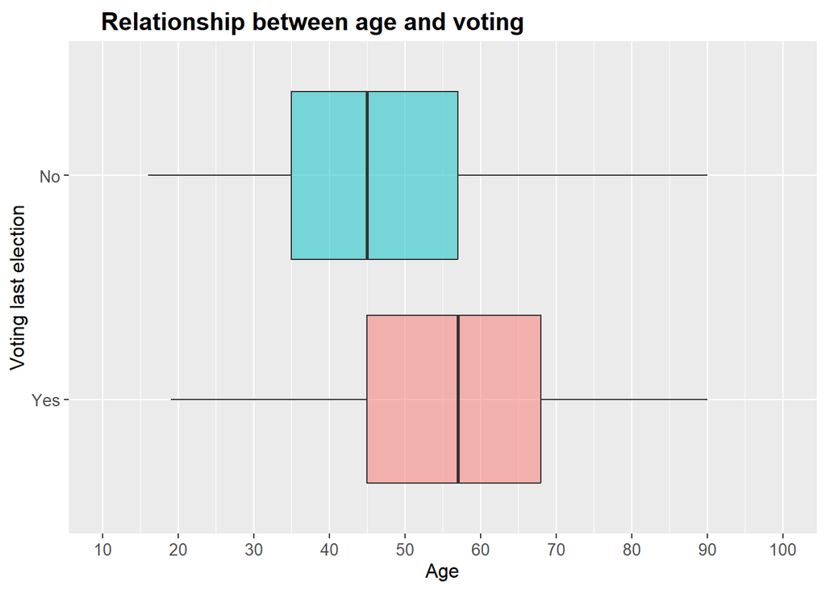

```r
ESS_pol = ESS_pol %>%
  filter(agea !=999)

ESS_pol = ESS_pol %>%
  filter(vote !=3) %>%
  filter(vote !=7) %>%
  filter(vote !=8) %>%
  filter(vote !=9)

ESS_pol$agea = as.numeric(as.character(ESS_pol$agea))
ESS_pol$vote <- factor(ESS_pol$vote, labels = c("Yes", "No"), ordered = F)

ggplot(ESS_pol) +
  geom_boxplot(aes(agea, vote, fill = vote), alpha = 0.5) +
  scale_x_continuous(limits=c(10,100),breaks=c(10, 20, 30, 40, 50, 60, 70, 80,
                                               90, 100)) +
  labs(title="Relationship between age and voting", x ="Age", y="Voting last election") +
  theme(plot.title = element_text(face="bold", size = 15, vjust = 0.5, hjust=0.1),
        axis.title.x = element_text(color="black", size=12),
        axis.title.y = element_text(color="black",size= 12),
        axis.text.y = element_text(size=10),
        axis.text.x = element_text(size=10),
        legend.position=("none"))
```

Conclusion 10: We can see from the plot that people from 60 to 70 (elder) vote more than other aged groups.

## Summary of Findings:

There is a relationship between people’s age and theirs participation in voting and signing the petitions. We can see that elder people more participate in voting and vice versa middle-aged people more signing petitions. There is not a relationship between how much time people spend on politics news and their satisfaction on national government and trust in a legal system. There is not difference in relation to trust in the police and people’s gender. Citizens of France mostly believe they are not able to take active role in political group. People mostly answered from 4 to 7 about their satisfaction with national government. There is not significantly difference between people’s voting and their confidence that the political system allows people to influence on politics. But there is group that said “a great deal” and this group mostly did not vote.

## Conclusion:

Thus, we have built all graphs and many results for us were a surprise. For example, we have supposed that time people spend on political news would influence on political participation and opinions about politics, but we have the opposite result. From research interesting we can see that we have proved second paper about age and political participation. In our graphs elder people more take part in politics as voting, middle-aged people more take part in politics as signing petitions. And in the second paper the results were the same. Therefore, we can conclude that demographic characteristics influence on people’s participation in France. We, also, can conclude that people’s opinion about different aspects of politics can influence on their participation in it. In the next parts of the project we will try to delve deeper into our results and tell more about them.

# Project 2

Research question: How does confidence in abilities for political participation differ between various demographic groups of French citizens?

Research interest: The main interest of this research is to see how demographic factors like age and gender might influence confidence in one’s political participation and, consequently, participation itself. Our research interest in looking at age as one of the demographic characteristics is driven by Goerres’(2009) objective that people of 50 years of age and older in democratic regimes with the majority voting rule are and will be the dominating and most influential voting group and will basically dictate the electoral politics (Goerres, 2009). This information might seem outdated since the book was published in 2009, however, based on our research we can surprisingly see that Goerres’ point about elderly people having more influence as a voting group is still relevant. As another demographic characteristic to look at, we chose gender. This intention can be explained with the concept “gender gap”, the idea of “unequal relationship between men and women in politics”(Mayer, 2015). According to Mayer, “women are latecomers on the electoral scene, especially in France where they got the right to vote one century after men”(Mayer, 2015). The author implies that this is what explains lower levels of political interest, confidence and perception of own abilities in political participation for women compared to men. This objective pointed to our interest in testing the hypothesis about association between one’s gender and their opinion on abilities for political participation.

References: Goerres, A. (2009). Introduction: The political participation of older people in an era of demographic ageing. In Palgrave Macmillan UK eBooks (pp. 1–21). https://doi.org/10.1057/9780230233959_1 Mayer, N. (2015). The closing of the radical right gender gap in France? French Politics, 13(4), 391–414. https://doi.org/10.1057/fp.2015.18

## Part I. Chi-squared Test

```r
#Variables:gender and able to take active role in political group
ESS_ctest = ESS_pol%>%
  dplyr::select(gndr, actrolga) %>%
  filter(actrolga != 8)%>%
  filter(actrolga!= 9)%>%
  filter(actrolga != 7)%>%
  filter(gndr!= 9)


ESS_ctest$actrolga<-factor(ESS_ctest$actrolga,labels=c("Not at all able","A little able",
  "Quite able","Very able","Completely able"),ordered=F,exclude=NA)
ESS_ctest$gndr<-factor(ESS_ctest$gndr,labels=c("Male","Female"),ordered = F, exclude = NA)
```

Checking for normality assumptions for running chi-square test:

There are many conditions, and they are all met, so we are all good to run the test: 1) data in cells is frequency and not percentage of something else 2) categories of variable are actually mutually exclusive 3) each subject contributed data only to one cell 4) study groups are independent 5) there are two nominal variables 6) the value of a cell expected is more than 5 in at least 80% of cases

Making hypotheses:

H0:There is no statistically significant association between citizens of France opinions on their ability to take active role in political group and their gender.

Ha:There is a statistically significant association between citizens of France opinions on their ability to take active role in political group and their gender.

Creating a contingency table.

```r
chi_table<-table(ESS_ctest$actrolga, ESS_ctest$gndr)
kable(chi_table)%>%
  kable_styling(bootstrap_options=c("bordered", "responsive", "striped"), full_width = FALSE)
```

|  | Male | Female |
| --- | --- | --- |
| Not at all able | 244 | 367 |
| A little able | 231 | 210 |
| Quite able | 183 | 144 |
| Very able | 53 | 35 |
| Completely able | 52 | 23 |

Visualizing the data.

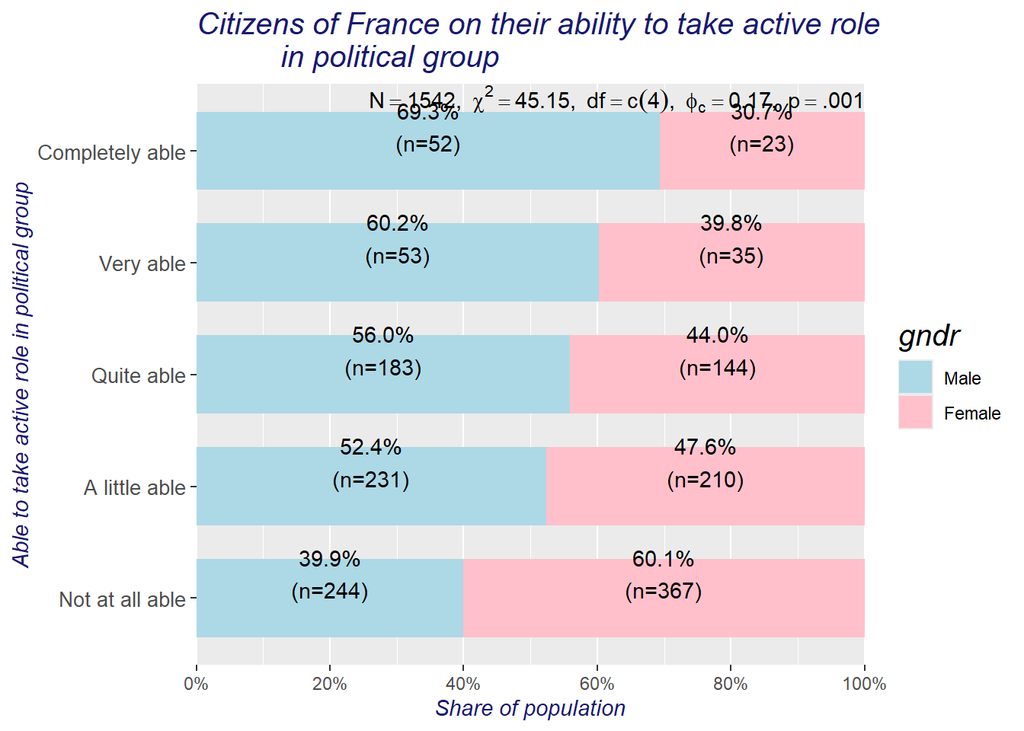

```r
plot_xtab(ESS_ctest$actrolga, ESS_ctest$gndr, margin = "row", bar.pos = "stack",
          show.summary = TRUE,summary.pos ="r")+
  scale_fill_manual(values=c("lightblue","pink"))+
  coord_flip()+
  xlab("Able to take active role in political group")+
  ylab("Share of population") +
  ggtitle("Citizens of France on their ability to take active role
          in political group") +
  theme(plot.title = element_text(face="italic",size = 15, color="midnightblue"),
        axis.title.x=element_text(face="italic", color = "midnightblue"),
        axis.title.y=element_text(face="italic", color = "midnightblue"),
        axis.text.y = element_text(size = 10),
        legend.title = element_text(face="italic", size = 15))
```

Running the chi-square test.

```r
chitest<-chisq.test(ESS_ctest$actrolga, ESS_ctest$gndr)
```

P-value is much smaller than 0.05, which means we can accept the alternative hypothesis that there actually is a statistically significant association between citizens of France opinions on their ability to take active role in political group and their gender.

Checking the expected and observed frequencies.

```r
chisq.test(ESS_ctest$actrolga, ESS_ctest$gndr)$observed
```

```
##                   ESS_ctest$gndr
## ESS_ctest$actrolga Male Female
##    Not at all able  244    367
##    A little able    231    210
##    Quite able       183    144
##    Very able         53     35
##    Completely able   52     23
```

```r
chisq.test(ESS_ctest$actrolga, ESS_ctest$gndr)$expected
```

```
##                   ESS_ctest$gndr
## ESS_ctest$actrolga      Male    Female
##    Not at all able 302.33009 308.66991
##    A little able   218.21206 222.78794
##    Quite able      161.80350 165.19650
##    Very able        43.54345  44.45655
##    Completely able  37.11089  37.88911
```

Analyzing standardized residuals.

```r
kable(chisq.test(ESS_ctest$actrolga, ESS_ctest$gndr)$stdres)
```

|  | Male | Female |
| --- | --- | --- |
| Not at all able | -6.074251 | 6.074251 |
| A little able | 1.441395 | -1.441395 |
| Quite able | 2.641178 | -2.641178 |
| Very able | 2.076370 | -2.076370 |
| Completely able | 3.525482 | -3.525482 |

The association plot will help us better understand the situation with standardized residuals:

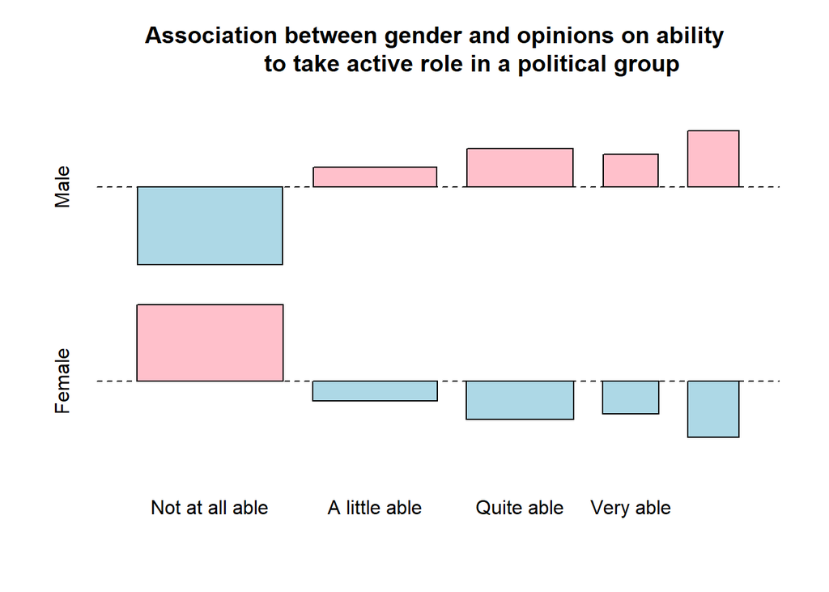

```r
assocplot(table(ESS_ctest$actrolga, ESS_ctest$gndr), main="Association between gender and opinions on ability
          to take active role in a political group",col=c("pink","lightblue"))
```

The graph visually proves our conclusions

## Part II. The t-test

Variables: vote and age

```r
ESS_ttest = ESS_pol %>%
  dplyr::select(agea, vote) %>%
  filter(agea !=999) %>%
  filter(vote != 3) %>%
  filter(vote != 7) %>%
  filter(vote != 8) %>%
  filter(vote != 9)

ESS_ttest$agea = as.numeric(as.character(ESS_ttest$agea))
ESS_ttest$vote <- factor(ESS_ttest$vote, labels = c("Yes", "No"), ordered = F)
```

Comparison mean values by boxplot:

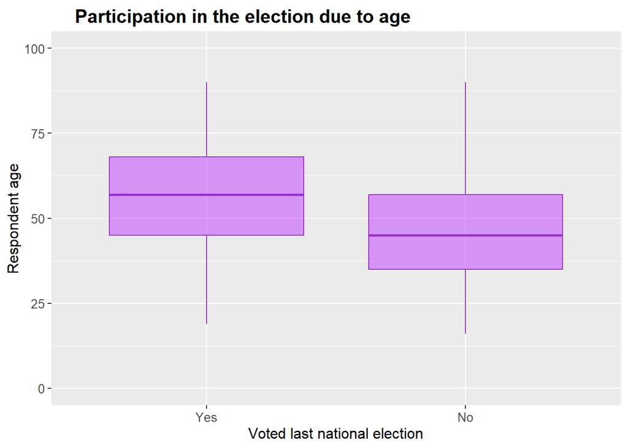

```r
ggplot() +
  geom_boxplot(data = ESS_ttest, aes(x = vote, y = agea), fill="#BF3EFF", col="#9A32CD", alpha = 0.5) +
  scale_y_continuous(limits = c(0,100)) +
  xlab("Voted last national election") +
  ylab("Respondent age") +
  ggtitle("Participation in the election due to age") +
  theme(plot.title = element_text(face="bold", size = 15, vjust = 0.5, hjust=0.1),
        axis.title.x = element_text(color="black", size=12),
        axis.title.y = element_text(color="black",size= 12),
        axis.text.y = element_text(size=10),
        axis.text.x = element_text(size=10),
        legend.position=("none"))
```

Conclusion: The median age of respondents who voted last election (~58 y.o.) is higher than the median age of respondents who did not vote last election (~45 y.o.)

The lengths of two box plots are the same, therefore, we can say that variety of ages is the same in these two groups. Also we cannot see the outliers.

Check the normality of distribution:

```r
describeBy(ESS_ttest, ESS_ttest$vote)
```

```
##
##  Descriptive statistics by group
## group: Yes
##      vars   n  mean    sd median trimmed   mad min max range  skew kurtosis  se
## agea    1 987 56.66 15.76     57   56.92 17.79  19  90    71 -0.13    -0.64 0.5
## vote    2 987  1.00  0.00      1    1.00  0.00   1   1     0   NaN      NaN 0.0
## ------------------------------------------------------------
## group: No
##      vars   n  mean    sd median trimmed   mad min max range skew kurtosis   se
## agea    1 555 46.73 15.87     45   45.78 16.31  16  90    74  0.5    -0.41 0.67
## vote    2 555  2.00  0.00      2    2.00  0.00   2   2     0  NaN      NaN 0.00
```

Skewness is a measure of the symmetry in a distribution and for normal distribution it must be zero (0). We can see in first group (who voted) that skew is -0.13 and we can say that as we have negative value for the skewness - it indicates first group that is skewed left. We can see in second group (who did not vote) that skew is 0.49 and we can say that we have positive value for skewness - it indicates second group that is skewed right

Therefore, we can say that skew and kurtosis indicates normal distribution.

Running Levene test for the equality of variances:

```r
leveneTest(ESS_ttest$agea ~ ESS_ttest$vote,ESS_ttest)
```

```
## Levene's Test for Homogeneity of Variance (center = median)
##         Df F value Pr(>F)
## group    1   1e-04 0.9925
##       1540
```

As we can see, variances are homogeneous since p value is 0.9925 which is mich higher than 0.05.

Check the normality by histogram:

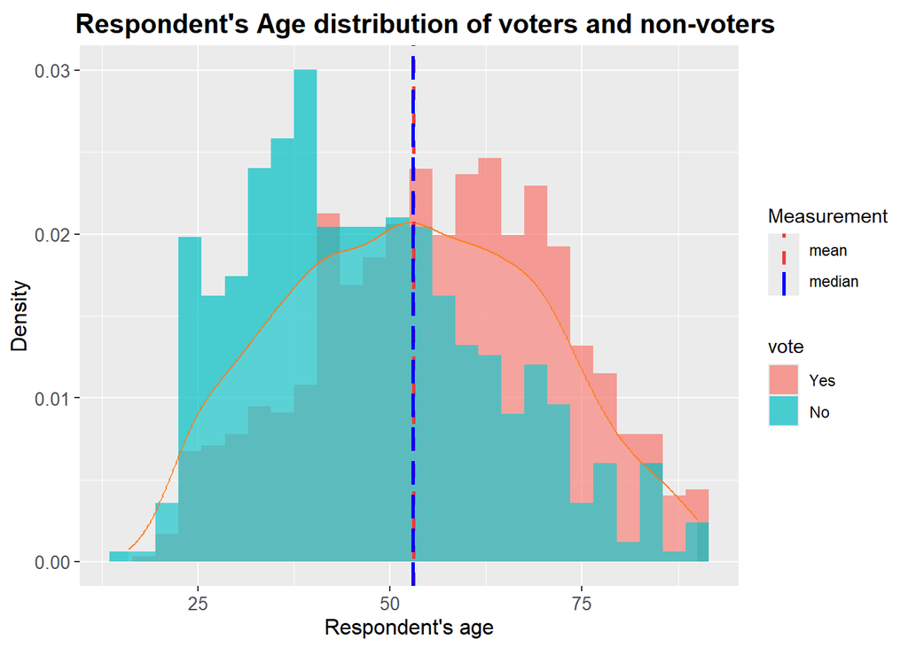

```r
ggplot(ESS_ttest, aes(x = agea, fill = vote)) +
  geom_histogram(aes(y=..density..), position = "identity", alpha = 0.7, binwidth = 3) +
  geom_density(col = "#FF7F24", fill = "white", alpha = 0.1) +
  geom_vline(aes(xintercept = mean(ESS_ttest$agea), color = 'mean'), linetype="dashed", size=1) +
  geom_vline(aes(xintercept = median(ESS_ttest$agea), color = 'median'), linetype="longdash", size=1) +
  scale_color_manual(name = "Measurement", values = c(median = "#0000FF", mean = "#EE3B3B")) +
  xlab("Respondent's age") +
  ylab("Density") +
  ggtitle("Respondent's Age distribution of voters and non-voters") +
  theme(plot.title = element_text(face="bold", size = 15, vjust = 0.5, hjust=0.1),
        axis.title.x = element_text(color="black", size=12),
        axis.title.y = element_text(color="black",size= 12),
        axis.text.y = element_text(size=10),
        axis.text.x = element_text(size=10))
```

We can see from histogram that these two group are not normally distributed. BUT group of respondents who voted is slightly closer to normal distribution, as it has more “territory” in a line.

Check the normality by QQ-plot: In France people can vote from 18 years old, therefore, in QQ-plot y will be limited by 18. Also, we need two create two groups: who vote and who do not vote.

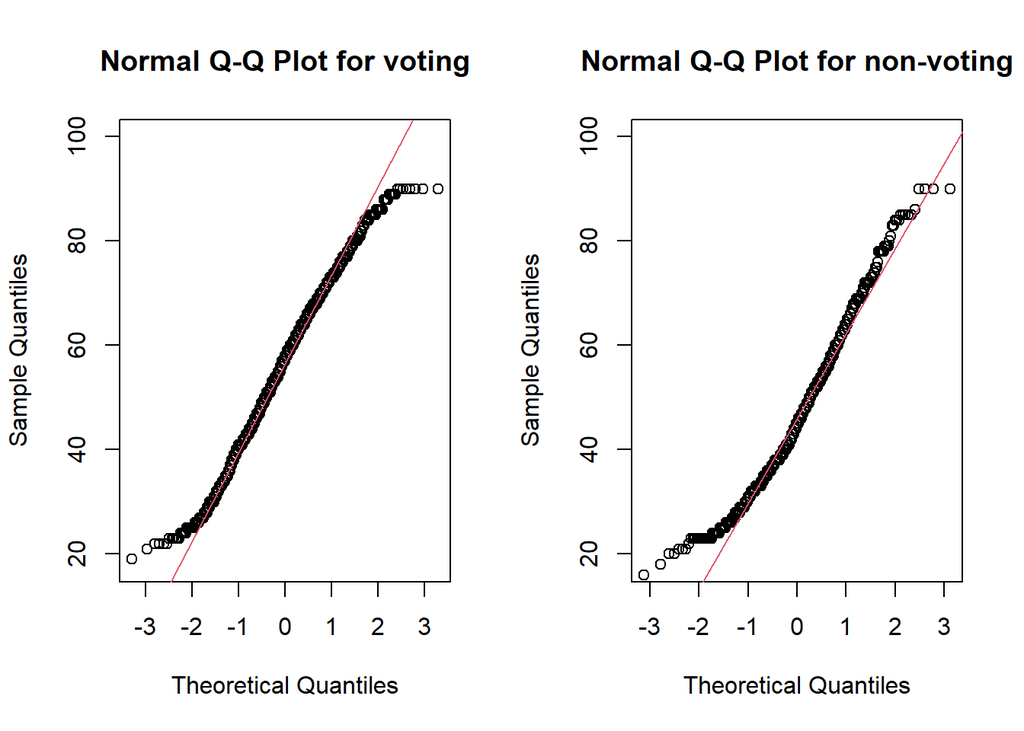

```r
vote_yes <- subset(ESS_ttest[ESS_ttest$vote == "Yes",])
vote_no <- subset(ESS_ttest[ESS_ttest$vote == "No",])
par(mfrow = c(1,2))
qqnorm(vote_yes$agea, ylim = c(18, 100), main = "Normal Q-Q Plot for voting"); qqline(vote_yes$agea,ylim = c(18 ,100), col= 2)
qqnorm(vote_no$agea, ylim = c(18 ,100), main = "Normal Q-Q Plot for non-voting"); qqline(vote_no$agea, col= 2, ylim = c(18 ,100))
```

We can see that two QQ-plots are not normally distributed because they have some values that are higher than our line. But we can say that first shows a slightly plainer speak.

Thus, we can conclude that the first group is slightly more normally distributed than second. BUT according to all our tests we can say that these two groups has abnormal distribution. Therefore, we need to use non-parametric test (not “normal” t-test). But by our task we need to do two t-tests.

We assume that age can influence on voting behavior from our second research (literature), therefore our hypothesis are: H0: the mean age of people who voted and did not vote does not differ. H1: the mean age does differ and, thus, there is a relation between age and voting behavior

To check our assumptions we need to conduct T-test:

```r
t.test(ESS_ttest$agea ~ ESS_ttest$vote)
```

```
##
##  Welch Two Sample t-test
##
## data:  ESS_ttest$agea by ESS_ttest$vote
## t = 11.818, df = 1142, p-value < 2.2e-16
## alternative hypothesis: true difference in means between group Yes and group No is not equal to 0
## 95 percent confidence interval:
##   8.27725 11.57276
## sample estimates:
## mean in group Yes  mean in group No
##          56.65653          46.73153
```

Statistical Conclusion: we have p-value < 2.2e-16, therefore, we can say that we can reject our null hypothesis.

Substantive conclusion: the mean age is significantly different among respondents who voted last election and who did not vote last election.

Since t-test has shown significant results, lets find cohens d:

```r
cohen.d(ESS_ttest$agea, ESS_ttest$vote)
```

```
## Call: cohen.d(x = ESS_ttest$agea, group = ESS_ttest$vote)
## Cohen d statistic of difference between two means
##      lower effect upper
## [1,] -0.73  -0.63 -0.52
##
## Multivariate (Mahalanobis) distance between groups
## [1] 0.63
## r equivalent of difference between two means
##  data
## -0.29
```

To check results with non-parametric test: H0: the two populations (voters and non-voters) have the same distribution with the same median age. H1: the two populations (voters and non-voters) have a different distribution with a different median age.

```r
wilcox.test(agea ~ vote, data = ESS_ttest)
```

```
##
##  Wilcoxon rank sum test with continuity correction
##
## data:  agea by vote
## W = 370896, p-value < 2.2e-16
## alternative hypothesis: true location shift is not equal to 0
```

Statistical conclusion: p-value < 2.2e-16 that is why we need to reject null hypothesis. Substantive conclusion: The Wilcoxon test also proves that the age of people from the considered groups is significantly different among those who voted, and those who refused to vote.